# Basic Fill and Spill Model

Yvette D. Hastings

2024-02-29

## Description and Conceptual Diagram

This is a basic fill and spill model that only incorporates values for input, the number of boundary layers, and field capacity and storage of water within each boundary layer. Area of each boundary layer is considered equal for this exercise.

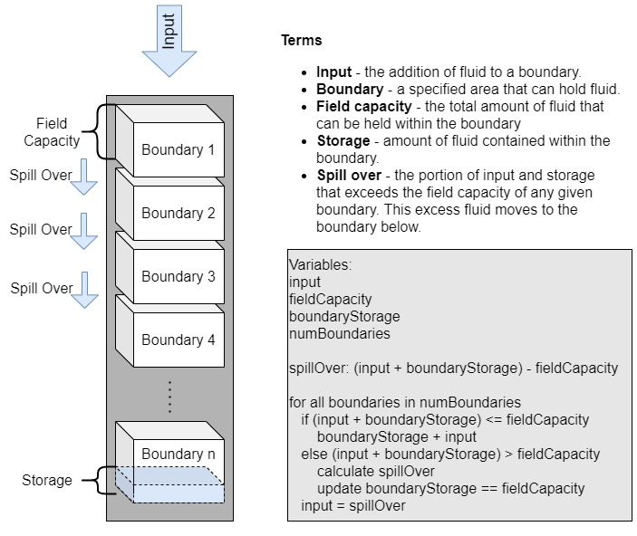

The following functions take user input and performs the following actions:

- Calculates spillover from one layer to the next
- Updates the storage value if the field capacity is exceeded
- Determines the difference between the original and new storage values
- Plots the initial storage, final storage, change in storage, and the porportion of water in each layer.

## Load Libraries

```r
library(ggplot2)
library(ggpubr)
```

## Load User Data

```r
##last boundary signifies groundwater storage; water has exceeded soil layer
testData <- data.frame(soilColumn = 'soilColumn',
                       numBoundary = c(1, 2, 3, 4, 5, 6, 7),
                       fieldCapacity = c(200, 10, 50, 90, 50, 100, 999999),
                       boundaryStorage = c(10, 10, 10, 20, 10, 20, 0))
testData
```

```
##   soilColumn numBoundary fieldCapacity boundaryStorage
## 1 soilColumn           1           200              10
## 2 soilColumn           2            10              10
## 3 soilColumn           3            50              10
## 4 soilColumn           4            90              20
## 5 soilColumn           5            50              10
## 6 soilColumn           6           100              20
## 7 soilColumn           7        999999               0
```

## Define Function

```r
##function
fill_n_spill <- function(input, data){

  input <- input
  data$originalStorage <- data$boundaryStorage
  data$spill_over <- NA
  data$Diff <- NA

  #loop through df
  for (i in 1:nrow(data)) {

    if((input + data[i, 'boundaryStorage']) <= data[i,'fieldCapacity']) {

      print(paste0("The amount of water in soil boundary ", i, " increased by: ", input))
      print(paste0("The final amount of water in soil boundary ", i, " is: ", input + data[i,'boundaryStorage']))
      cat("\n")

      #add final spill over value to last boundaryStorage
      data[i, 'boundaryStorage'] <- data[i,'boundaryStorage'] + input
      break
    }

    else if((input + data[i,'boundaryStorage']) > data[i,'fieldCapacity']){

      spillOver <- (input + data[i,'boundaryStorage']) - data[i,'fieldCapacity'] #calculate spill over
      data[i, 'spill_over'] <- spillOver

      data[i, 'boundaryStorage'] <- data[i, 'fieldCapacity'] #update boundary storage

      print(paste0("The amount of spillover in boundary ", i, " entering boundary ", i+1, " is: ", spillOver))
      cat("\n")

    }
    input <- spillOver #update the input to equal spill over for each loop
  }
  data[, 'Diff'] <- data['boundaryStorage'] - data['originalStorage'] #calculate the change in storage
  print(data)

  #graph
  storage_pre <- ggplot(data, aes(x = numBoundary, y = originalStorage, fill = numBoundary)) +
    geom_bar(stat = 'identity') +
    theme_classic() +
    xlab("Boundary Layer Number") + ylab("Amount of Water in Storage") + ggtitle("Original Water in Storage by Soil Layer") +
    scale_x_continuous(breaks = round(seq(min(data$numBoundary), max(data$numBoundary))))  +
    scale_fill_continuous(name = "Soil Boundary Layer") +
    theme(legend.key.size = unit(0.75, 'cm')) +
    scale_y_continuous(limits = c(0, max(data$boundaryStorage)), expand = c(0,0))

  storage_post <- ggplot(data, aes(x = numBoundary, y = boundaryStorage, fill = numBoundary)) +
    geom_bar(stat = 'identity') +
    theme_classic() +
    xlab("Boundary Layer Number") + ylab("Amount of Water in Storage") + ggtitle("Final Water in Storage by Soil Layer") +
    scale_x_continuous(breaks = round(seq(min(data$numBoundary), max(data$numBoundary)))) +
    scale_y_continuous(limits = c(0, max(data$boundaryStorage)), expand = c(0,0))+
    scale_fill_continuous(name = "Soil Boundary Layer")

  storage_increase <- ggplot(data, aes(x = numBoundary, y = Diff, fill = numBoundary)) +
    geom_bar(stat = 'identity') +
    theme_classic() +
    xlab("Boundary Layer Number") + ylab("Change in Storage") + ggtitle("Change in Storage For Each Layer") +
    scale_x_continuous(breaks = round(seq(min(data$numBoundary), max(data$numBoundary)))) +
    scale_y_continuous(limits =  c(0, max(data$boundaryStorage)), expand = c(0,0)) +
    scale_fill_continuous(name = "Soil Boundary Layer")

  entirecolumn <- ggplot(data, aes(x = soilColumn, y = boundaryStorage, fill = numBoundary)) +
    geom_bar(position = 'stack', stat = 'identity', width = 0.5) +
    theme_classic() +
    xlab("Soil Column") + ylab("Volume of Water") + ggtitle("Volume of Water Stored in Each Soil Layer") +
    theme(legend.position = 'right',
          axis.text.x = element_blank(),
          axis.ticks = element_blank()) +
    scale_y_continuous(expand = c(0,0)) +
    scale_fill_continuous(name = "Soil Boundary Layer")

  ggarrange(storage_pre, storage_post, storage_increase, entirecolumn,
            nrow = 2, ncol = 2, labels = c('A', 'B', 'C', 'D'), common.legend = TRUE, legend = 'right')
}
```

## Test function and output

```r
fill_n_spill(419, testData)
```

```
## [1] "The amount of spillover in boundary 1 entering boundary 2 is: 229"
##
## [1] "The amount of spillover in boundary 2 entering boundary 3 is: 229"
##
## [1] "The amount of spillover in boundary 3 entering boundary 4 is: 189"
##
## [1] "The amount of spillover in boundary 4 entering boundary 5 is: 119"
##
## [1] "The amount of spillover in boundary 5 entering boundary 6 is: 79"
##
## [1] "The amount of water in soil boundary 6 increased by: 79"
## [1] "The final amount of water in soil boundary 6 is: 99"
##
##   soilColumn numBoundary fieldCapacity boundaryStorage originalStorage
## 1 soilColumn           1           200             200              10
## 2 soilColumn           2            10              10              10
## 3 soilColumn           3            50              50              10
## 4 soilColumn           4            90              90              20
## 5 soilColumn           5            50              50              10
## 6 soilColumn           6           100              99              20
## 7 soilColumn           7        999999               0               0
##   spill_over Diff
## 1        229  190
## 2        229    0
## 3        189   40
## 4        119   70
## 5         79   40
## 6         NA   79
## 7         NA    0
```

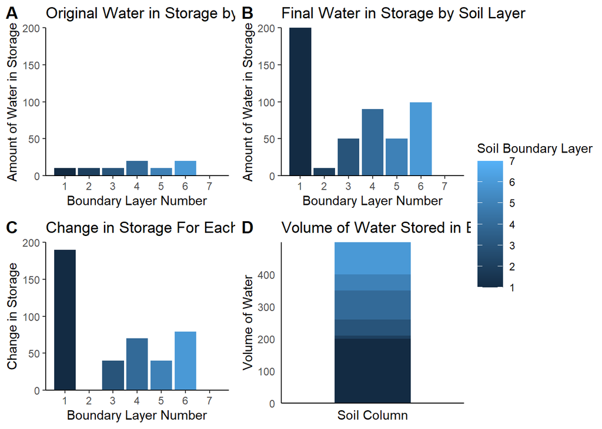

## Time Stepping Added to Function

The time stepping function does the same thing as the basic fill and spill model from above and also adds a time value (1,2,3,…,n) where n is the length of the user input list. The function then iterates through the data file provided by the user and then increments and repeats with the next time step.

```r
fill_n_spill_time_step <- function(input, data){

  input <- input
  data$originalStorage <- data$boundaryStorage
  data$spill_over <- NA
  data$Diff <- NA

  inflow <- data.frame(time = "NA",
                       inflow = "NA",
                       groundWaterChange = "NA")

  for(i in 1:length(input)) {
    inflow[i, 'time'] <- i
    inflow[i, 'inflow'] <- input[i]

    inflow <- transform(inflow, time = as.numeric(time),
                        inflow = as.numeric(inflow))}

  for(i in 1:nrow(inflow)) {

    #loop through df
    for (x in 1:nrow(data)) {

      print(paste0('The current time step is: ', inflow[i, 'time']))

      if((inflow[i, 'inflow'] + data[x,'boundaryStorage']) <= data[x,'fieldCapacity']) {

        print(paste0("The final amount of water in soil boundary ", x, " is: ", inflow[i, 'inflow'] + data[x,'boundaryStorage']))
        cat("\n")

        #add final spill over value to last boundaryStorage
        data[x, 'boundaryStorage'] <- inflow[i, 'inflow'] + data[x,'boundaryStorage']

        if((tail(data$boundaryStorage, n=1) != 0) != 0) {
          inflow[i, 'groundWaterChange'] <- data[x, 'boundaryStorage']
        } else {
          inflow[i, 'groundWaterChange'] <- 0
        }
        print(data)
        break
      } else if((inflow[i, 'inflow'] + data[x,'boundaryStorage']) > data[x,'fieldCapacity']){

        spillOver <- (inflow[i, 'inflow'] + data[x,'boundaryStorage']) - data[x,'fieldCapacity'] #calculate spill over
        data[x, 'spill_over'] <- spillOver
        data[x, 'boundaryStorage'] <- data[x, 'fieldCapacity'] #update boundary storage
        print(paste0("The amount of spillover in boundary ", x, " entering boundary ", x+1, " is: ", spillOver))
        cat("\n")

      }
      inflow[i, 'inflow'] <- spillOver #update the input to equal spill over for each loop
      }
  }

  for(i in 1:length(input)) {
    inflow[i, 'inflow'] <- input[i]
    inflow <- transform(inflow, groundWaterChange = as.numeric(groundWaterChange))
    }

  print(inflow)

  ggplot(inflow, aes(x = time, y = groundWaterChange)) +
    geom_bar(stat = 'identity', fill = 'steelblue') +
    ggtitle('Groundwater Change Over Time') +
    xlab('Time Step') +
    ylab('Volume of Groundwater') +
    scale_y_continuous(limits =  c(0, max(inflow$groundWaterChange)), expand = c(0,0)) +
    theme_classic() +
    theme(plot.title = element_text(hjust = 0.5))
}
```

## Testing the time step function

Use fill_n_spill_time_step(input, data), where input is the amount of water entering (as a single integer or list) and data is the user data (as a df).

```r
fill_n_spill_time_step(c(250,30,200,500,20), testData)
```

```
## [1] "The current time step is: 1"
## [1] "The amount of spillover in boundary 1 entering boundary 2 is: 60"
##
## [1] "The current time step is: 1"
## [1] "The amount of spillover in boundary 2 entering boundary 3 is: 60"
##
## [1] "The current time step is: 1"
## [1] "The amount of spillover in boundary 3 entering boundary 4 is: 20"
##
## [1] "The current time step is: 1"
## [1] "The final amount of water in soil boundary 4 is: 40"
##
##   soilColumn numBoundary fieldCapacity boundaryStorage originalStorage
## 1 soilColumn           1           200             200              10
## 2 soilColumn           2            10              10              10
```

[output cut: 158 more lines]

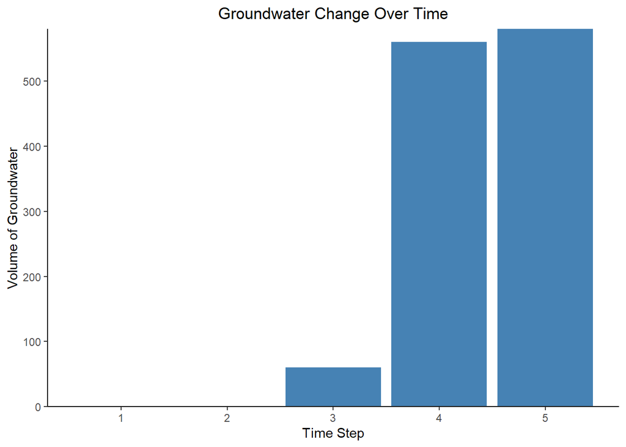